# Predictive Analysis Using kNN an Naive Bayes

Aliyu S. Sambo  
9th Dec. 2016

### Initial Naive Bayes Predictive Analysis Result

Initial Naive Bayes prediction performance for Fbs (Fasting Blood Sugar) was poor.

Below shows a comparison of the result for Fbs and Heart Disease predictions using the same model.

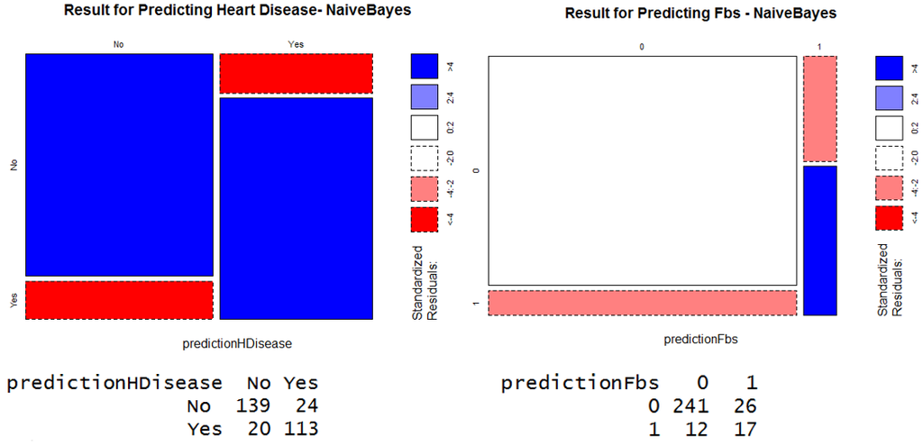

### Initial kNN Predictive Analysis Result

Below are the prediction results using a kNN model for both Fbs and Heart Disease prediction.The result of the Fbs prediction showed very poor performance and predict all as false. While the heart disease showed a decent level of performance.

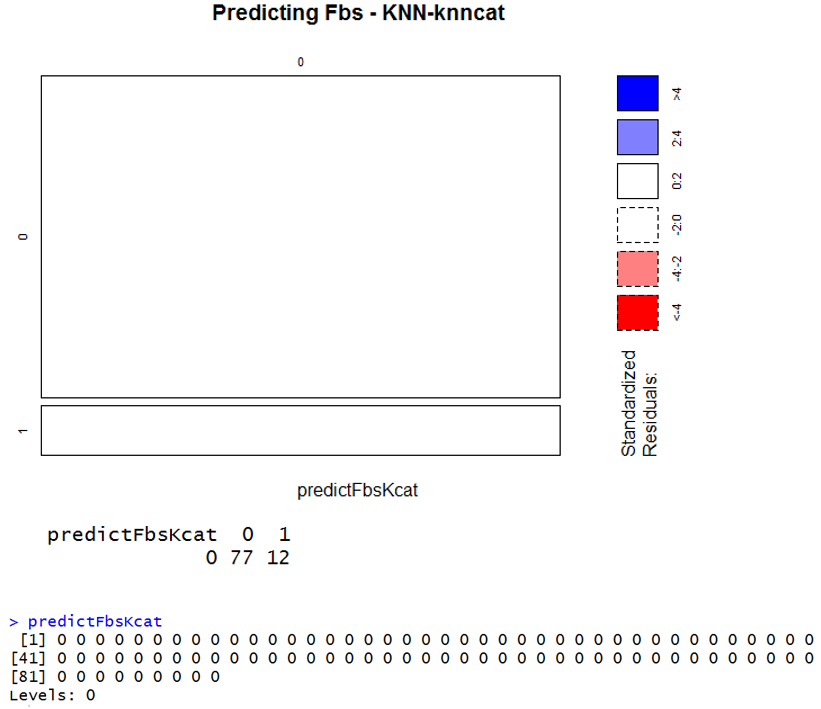

This indicates that the problem was not with the models but with the data.

### Improvement Efforts

Feature Selection: The RELIEF and RELIEFCAT algorithms were used to identify features that features that were key.

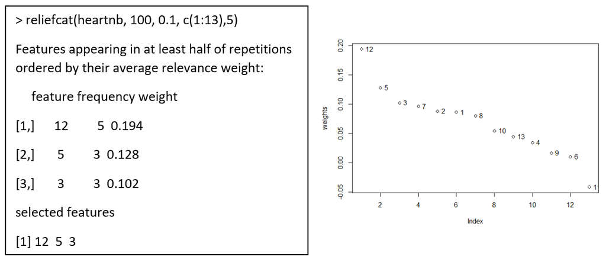

There was marginal improvements but not significant.

### Improvement Efforts (Contd)

Some improvement efforts showed marginal improvement on the Naive Bayes but the kNN result for Fbs was still very poor. Examples are as follows:

- Rescaling of Numeric Attribute
- Binning of Numeric Attributes and apply knncat (a knn algorithm that handles categorical data)
- Optimal K parameter was chosen for the model. This was done by testing for odd numbers around the square root of the number of rows of the training data.

```r
round(sqrt(nrow(heart.train)))
```

```
[1] 15
```

Therefore tried k= c(7, 9, 11, 13, 15, 17, 19). There was some improvement when k=13 was used.

### Identified Cause for Poor Performance

'Class Imbalance' was identified as the cause of poor result for predicting Fbs. Many predictive models perform best when the distribution is close to 50% by 50%.

```r
table(heart$Fbs)
```

```
  0   1
258  45
```

```r
table(heart$HDisease)
```

```
 No Yes
164 139
```

### Solution

There are two class imbalance mitigation approaches:

- Cost function based approaches
- Sampling based approaches: Oversampling/Undersampling/Hybrid

Oversampling (adding more of the minority class) was implemented using a function in ROSE package.

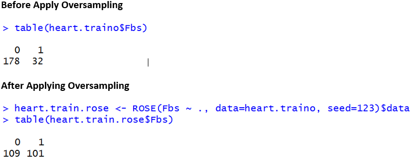

### Result After Mitigating for Class Imbalance

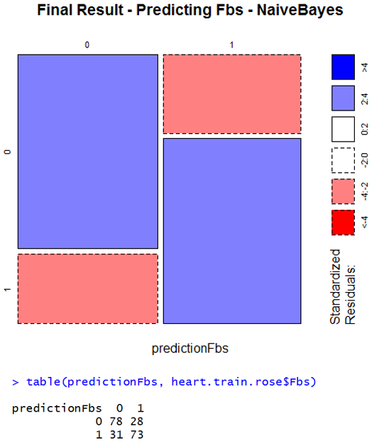